# Bootstrap

## 1. Motivation

어떠한 분포($F$:cdf)로부터 랜덤샘플 $X_1,\ldots,X_n$을 뽑았다고 가정하자. 만약 우리가 어떠한 통계량의 표본분포를 알고자 한다면 그것은 원래 모집단의 분포에 의존하게 될 것이다.

예를 들어 표본평균의 평균은 모집단의 평균과 일치하고 분산은 모집단의 분산을 표본의 수로 나눈 것과 같다.

표본분포의 이해를 위해서는 모집단의 분포에 대한 정보가 필수적이나 모집단에 대한 정보는 거의 없거나 제한적인 경우가 대부분이다. 붓스트랩의 핵심적인 아이디어는 모집단의 분포함수 $F$를 그 추정량 $\hat F$로 대체하여 추정량의 표본분포를 찾는 것이다.

$\hat F$을 마치 모집단의 분포함수처럼 생각한다면, 여러 번 반복해서 샘플링을 하는 것이 가능하며, 이를 기초로 하여 표본분포를 추정하게 된다. $\hat F$로부터 뽑힌 표본을 붓스트랩 샘플이라고 하며 이는 $X_1,\ldots,X_n$으로부터 복원추출로 $n$의 크기를 가지는 표본을 뽑는 것과 같다 ($X_1^\ast,\ldots,X_n^\ast$).

## 2. Plug-in estimator

많은 모수들이 $F$의 functional 형태로 표현될 수 있다. 예를 들면,

- moment

$\mu_k(F)=\int x^k dF(x)$

- central moment

$\omega_k(F)=\int (x-\mu_1(F))^k dF(x)$

- $p$-th quantile

$\xi_p(F)=\inf\{ x:F(x) \geq p \}$

와 같은 것들이 있다.

만약 우리가 경험적분포함수(EDF:empirical distribution function) $\hat F_n(x)=(1/n)\sum_{i=1}^n I(X_i \leq x)$로 $F$를 대체한다면,

$\hat\mu_k(F)=\mu_k(\hat F_n)=\int x^k d\hat F_n(x)=(1/n)\sum_{i=1}^n X_i^k$ $\hat\omega_k(F)=\omega_k(\hat F_n)=\int (x-\mu_1(\hat F_n))^k d\hat F_n(x)=(1/n)\sum_{i=1}^n (X_i - \bar X)^k$ $\hat\xi_p(F)=\xi_p(\hat F_n)=\inf\{ x:\hat F_n(x) \geq p \}$

와 같은 추정량을 얻게 된다.

## 3. Applications

#### 3.1 Estimation of variance

분산은 산포를 나타내는 분포의 측도이다. 분산은 그 자체로 관심대상이 되기도 하지만 신뢰구간을 구성할 때나 검정등을 수행할 때에도 추정이 필요한 중요한 값이라 할 수 있다.

추정량이 비교적 간단한 경우에는 추정량의 분산이 간단한 형태로 표현되고 또 추정될 수 있다. 예를 들어 표본평균의 분산은 $\sigma^2/n$으로 주어지고 $\sigma^2$은 MLE 혹은 표본분산 등에 의해 간단하게 추정할 수 있다. 하지만, 추정량이 복잡한 경우에는 분산의 형태를 정확하게 계산하는 것이 어려울 수 있다. 그리고 계산이 가능하다 하더라도 포함하고 있는 모수들이 추정이 어렵거나 효율적 추정이 어려운 경우에는 분산의 추정에도 좋지 않은 영향을 줄 수 있다.

예를 들어 표본중앙값($m$)의 분산에 관심이 있다고 해 보자. 대표본이론에 의하면 표본의 크기가 충분히 클 때

$var(m)\approx \frac{1}{4nf(\xi_{0.5})},~f:density$

임이 알려져 있다. 하지만 위와 같은 사실을 이끌어 내는 과정이 상대적으로 복잡하고 또한 $f$를 정확하게 추정하는 것이 상대적으로 쉽지 않음이 알려져 있다.

붓스트랩은 시뮬레이션에 기초한 방법으로 추정량이 복잡한 형태이더라도 그 적용에 전혀 문제가 없다. 위 문제를 붓스트랩을 적용하여 해결하는 과정을 간단히 기술해 보자.

먼저, 붓스트랩 샘플을 뽑는 과정을 $B$번 반복한다. 각각을 $X^\ast_b = (X_{b1}^\ast,\ldots,X_{bn}^\ast),~b=1,\ldots,B$라 하고, 각 샘플에 대해서 표본중앙값 $m_b^\ast$를 각각 계산한다. 이들이 마치 표본중앙값의 표본분포에서 뽑힌 $B$개의 표본과 같은 역할을 하게 된다. 즉, 표본중앙값의 분산에 대한 추정량은

$\hat{var}(m)^\ast = \frac{1}{B}\sum_{b=1}^B\left(m_b^\ast - \frac{1}{B}\sum_{i=1}^Bm_b^\ast\right)^2$

이 된다. 이는 $m_b^\ast$의 표본분산의 형태이며 이와 같은 방법으로 얻어지는 추정량을 붓스트랩추정량(Bootstrap estimator)라 한다.

일반적으로 어떤 모수 $\theta(F)$에 대한 추정량 $T(X)$의 분산은 다음과 같이 추정된다.

$\hat{var}(T(X))^\ast = \frac{1}{B}\sum_{b=1}^B\left(T(X^\ast_b) - \frac{1}{B}\sum_{i=1}^BT(X^\ast_b)\right)^2$

여기서 $T(X^\ast_b)$는 $b$번째 붓스트랩 표본으로부터 계산된 추정량이다.

- Example : LSAT & GPA scores

```r
LSAT<-c(576,635,558,578,666,580,555,661,651,605,653,575,545,572,594)
GPA<-c(3.39,3.30,2.81,3.03,3.44,3.07,3.00,3.43,3.36,3.13,3.12,2.74,2.76,2.88,2.96)
median(LSAT)
```

```
## [1] 580
```

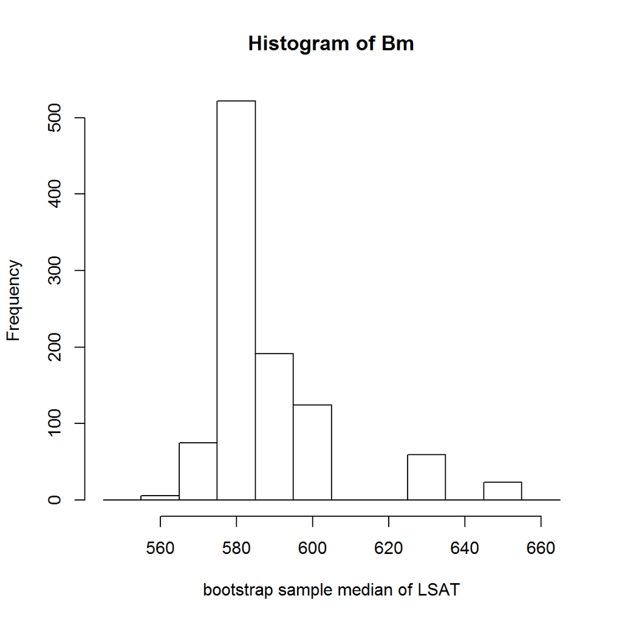

```r
B=1000
BS=matrix(0,B,length(LSAT))
Bm=c()
set.seed(1)
for (i in 1:B)
  {
  BS[i,]=sample(LSAT,replace=TRUE)
  Bm[i]=median(BS[i,])
  }
hist(Bm,breaks=seq(min(LSAT),max(LSAT),10),xlab="bootstrap sample median of LSAT")
```

```r
mean(Bm)
```

```
## [1] 589.246
```

```r
var(Bm)
```

```
## [1] 333.4649
```

#### 3.2 Bias-reduction

위와 비슷하게 어떤 추정량의 편의를 다음과 같이 추정할 수 있다.

$\hat{bias}(T(X))^\ast = \frac{1}{B}\sum_{b=1}^B T(X^\ast_b) - \theta(\hat F_n)$

$\theta(\hat F_n)$는 보통 $T(X)$와 일치하는 경우가 많다.

따라서, 편의를 제거한 추정량은

$T(X)-\hat{bias}(T(X))^\ast = 2T(X) - \frac{1}{B}\sum_{b=1}^B T(X^\ast_b)$

가 된다.

- Example : LSAT & GPA scores (revisited)

```r
Bb=mean(Bm)-median(LSAT)
bce=median(LSAT)-Bb
Bb # Bootstap bias
```

```
## [1] 9.246
```

```r
bce # bias corrected estimator
```

```
## [1] 570.754
```

#### 3.3 Confidence interval

특정 모수에 대한 신뢰구간을 구성하려면 추정량의 분산에 대한 정보가 필요하다. 예를 들어 모평균에 대한 신뢰구간은

$\bar X \pm z_{\alpha/2} \sigma/\sqrt{n}$

과 같은 형태로 주어진다. 즉, 신뢰구간을 구성하는 문제는 앞에서 언급했던 분산의 추정 문제로 귀결될 수 있다. 하지만, 이것 또한 추정량의 (점근)분포가 정규분포일때에만 적용가능하며, 만약 그렇지 않다면 분위수에 대한 추정이 추가로 필요할 것이다.

###### 3.3.1 Normal interval

만약 추정량의 분포가 (점근적으로) 정규분포라고 할 수 있다면, 분산을 붓스트랩에 근거하여 추정하여

$T(X) \pm z_{\alpha/2} \sqrt{\hat{var}(T(X)^\ast)}$

와 같은 붓스트랩 신뢰구간을 구성할 수 있다.

- Example : C.I. for the sample median of LSAT scores (revisited)

```r
TX=median(LSAT);Bv=var(Bm)
c(TX-qnorm(0.975)*sqrt(Bv),TX+qnorm(0.975)*sqrt(Bv))
```

```
## [1] 544.2091 615.7909
```

###### 3.3.2 Pivotal interval

만약 추정량의 분포가 정규분포라는 가정을 하기 어렵다면, 추정량의 표본분포에 대한 정보를 그대로 이용하여 신뢰구간을 구성하여야 한다. 신뢰구간을 구성하는 기본적인 idea를 되새겨 보자. $\theta(F)$에 대한 추정량을 $T(X)$라 하고 $T(X)-\theta(F)$의 분포함수를 $H$라 하자. 여기서 $T(X)-\theta(F)$를 피봇(pivot)이라 한다. $H$의 하위 $\alpha$ 분위수를 $u_\alpha$라 하면 다음과 같은 확률식을 쓸 수 있다.

$P(u_{\alpha/2}\leq T(X)-\theta(F)\leq u_{1-\alpha/2})=1-\alpha.$

핵심 idea는 $u_{\alpha/2}$, $u_{1-\alpha/2}$를 붓스트랩에 근거하여 추정하는 것이다. 즉, $B$회의 샘플링에 의해 얻어진 $B$개의 추정량의 표본분위수로 위 분위수들을 추정한다. 이를 $u_{\alpha/2}^\ast$, $u_{1-\alpha/2}^\ast$라 하면, $\theta(F)$에 대한 $100(1-\alpha)\%$ 신뢰구간은

$(T(X)-u_{1-\alpha/2}^\ast,T(X)-u_{\alpha/2}^\ast)$

가 된다.

단, 위 분위수들은 $T(X)$가 아니라 $T(X)-\theta(F)$의 분포의 분위수이다. $\theta(F)$는 미지의 모수이므로 실제로는 위 분위수들을 바로 얻는 것은 불가능하다. 하지만, $T(X)$의 분포의 분위수를 $v_{\alpha/2}$, $v_{1-\alpha/2}$라 하면,

$u_{\alpha/2} = v_{\alpha/2} - \theta(F)$

와 같은 등식이 성립한다. $v_{\alpha/2}$는 붓스트랩에 의해 추정가능하고, $\theta(F)$는 $\theta(\hat F_n)=T(X)$로 추정가능하므로

$u_{\alpha/2}^\ast = v_{\alpha/2}^\ast - T(X)$

를 얻을 수 있다. 따라서, 붓스트랩에 의한 신뢰구간은

$(2T(X)-v_{1-\alpha/2}^\ast,2T(X)-v_{\alpha/2}^\ast)$

와 같이 주어진다.

- Example : C.I. for the sample median of LSAT scores (revisited)

```r
bq=quantile(Bm,probs=c(0.025,0.975))  # 95% C.I.
c(2*TX-bq[2],2*TX+bq[1])
```

[output not shown]

###### 3.3.3 Percentile interval

Pivotal interval보다 더욱 간단한 형태로 주어지는 신뢰구간이다.

$(v_{\alpha/2}^\ast,v_{1-\alpha/2}^\ast)$

이 신뢰구간은 $\phi(T(X))-\phi(\theta(F))$가 0을 중심으로 대칭인 분포가 되는 적절한 변환함수 $phi$가 존재하는 경우에만 정당화될 수 있는 것으로 알려져 있다. 즉, 편의추정량에 대해서는 좋은 신뢰구간을 제시할 수 없을 것이다.

- Example : C.I. for the sample median of LSAT scores (revisited)

```r
c(bq[1],bq[2])
```

```
##  2.5% 97.5%
##   575   635
```

- (HW) LSAT와 GPA 점수사이의 상관계수에 대하여
1. 표본상관계수를 계산하여라.
2. 표본상관계수의 평균 및 분산을 붓스트랩에 의해 추정하여라.
3. 표본상관계수의 분포를 히스토그램 및 density() 함수(R)에 의해 살펴보아라.
4. 모상관계수에 대한 95% 신뢰구간을 위에서 언급한 3가지 방식에 의하여 구성하여 보고 각 방식들이 정당한지 기술하여 보아라.

#### 3.4 Parametric Bootstrap

지금까지는 모집단의 분포함수 $F$를 EDF인 $\hat F_n$으로 추정하여 붓스트랩을 적용하였다. 즉, 모집단의 분포에 아무런 가정을 하지 않고 비모수적으로 추정한 것이다.

만약, $F$에 대한 사전정보가 있거나 모수적인 방법으로 정확히 추정이 가능하다면, 그렇게 하는 것이 더 효율적일 수 있다.

즉, 분포함수가 어떠한 모수 $\gamma$에 의존하여 $F_\gamma$의 형태로 표현가능하다고 할 때, $\gamma$를 추정한 후 $F_{\hat\gamma}$로 $F$를 추정하는 것이다.

$F_{\hat\gamma}$로부터 붓스트랩 표본을 추출할 때는 일반적인 방법들, 즉 inverse method나 acceptance rejection method 등을 사용하면 된다.

위 절의 예에서 LSAT 점수가 정규분포를 따른다고 가정할 수 있다면, 표본평균과 표본분산으로 LSAT의 분포를 먼저 추정한 후 추정된 정규분포에서 붓스트랩 표본을 추출한다.

- Example : LSAT - parametric Boiotstrap (revisited)

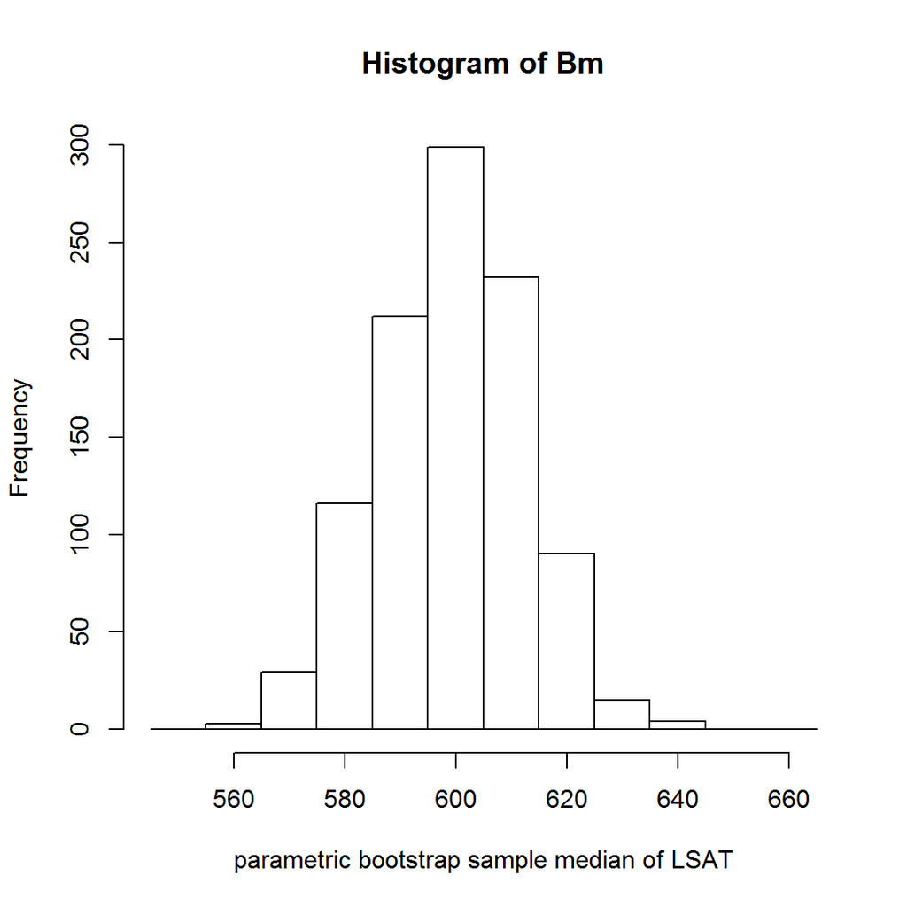

```r
BS=matrix(0,B,length(LSAT))
Bm=c()
sm=mean(LSAT);ss=sd(LSAT)
set.seed(1)
for (i in 1:B)
  {
  BS[i,]=rnorm(length(LSAT),sm,ss)
  Bm[i]=median(BS[i,])
  }
hist(Bm,breaks=seq(min(LSAT),max(LSAT),10),xlab="parametric bootstrap sample median of LSAT")
```

```r
mean(Bm)
```

```
## [1] 599.3601
```

```r
var(Bm)
```

```
## [1] 168.8779
```

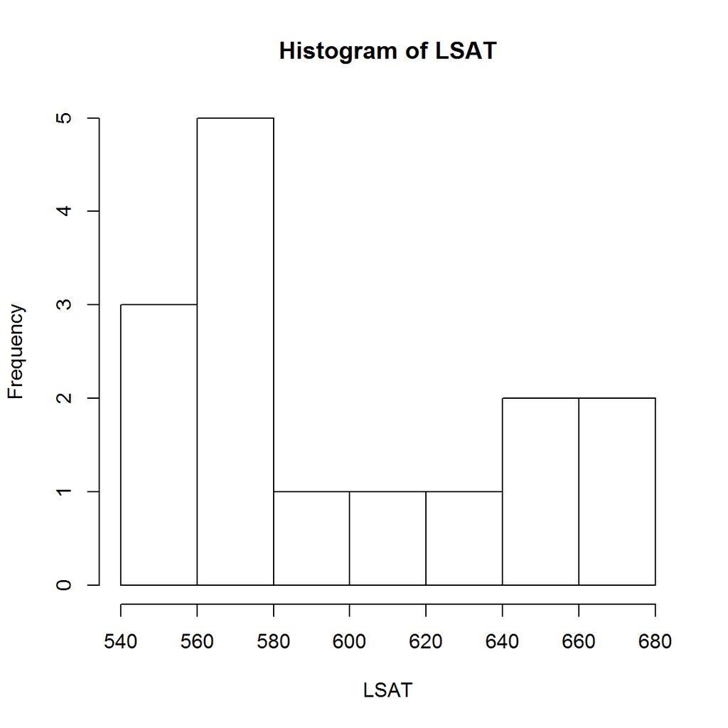

```r
hist(LSAT) # IS it really normally distributed?
```

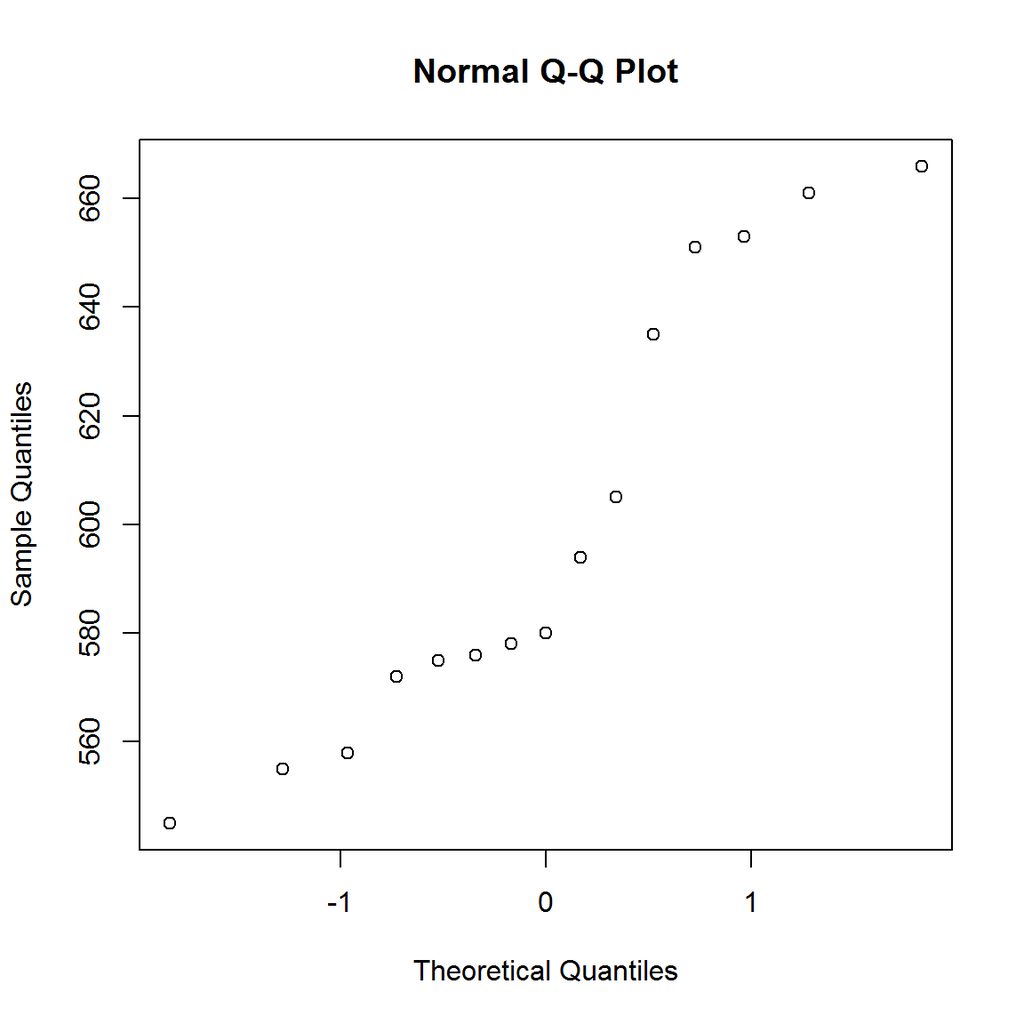

```r
qqnorm(LSAT)
```